# Sissejuhatus R-i ja RStudiosse

Indrek Soidla

2024-09-04

Käesoleva juhendmaterjali eesmärk on tutvuda mõningate R-i/RStudio eripärade, tööpõhimõtete ja andmete töötlemisel esmavajalike funktsioonidega.

## RStudio

Kui te avate RStudio esimest korda, siis näete akent jaotatuna kolmeks osaks. Vasakul on **konsooliaken**, kuhu saab käsureale käske sisestada ja neid ükshaaval käivitada. Ükshaaval käskude sisestamine võib aga kujuneda vaevarikkaks, seetõttu saab ka avada olemasoleva **skriptifaili** (*File* => *Open File*) või teha uue skriptifaili (*File* => *New File* => *R Script*) – sel juhul on **skriptifail vaikeseadena vasakul üleval, konsool vasakul all**. Parempoolsel ülemisel aknal on mitu paani, avatud peaks olema *Environment*, milles hakatakse töö käigus näitama mälus olevaid objekte (andmestikud ja muud tüüpi andmeobjektid). Paremal all on väljundaken, kus on samuti erinevaid paane, töö käigus näeme seal nt jooniseid (paan *Plots*) või kui küsime R-lt abi, näidatakse seal erinevate funktsioonide abifaile (paan *Help*).

Kõige lihtsamad asjad, mida R-s saame teha, on tavalised arvutused. Proovi konsooli kirjutada nt `1 + 2` ja vajuta Enter. Vastuseks peaks tulema `3` (käesolevas tekstis on tehte tulemus esitatud allpool kujul `## [1]` - trellid näitavad, et tegu on väljundiga, mis esitatakse konsooliaknas, `[1]` näitab, et vastus koosneb ühest elemendist, antud juhul arvust; see on tehniline notatsioon, mis esialgu tähtsust ei oma).

```r
1 + 2
```

```
## [1] 3
```

Saab ka natuke keerulisemaid arvutusi teha (tee kaasa või proovi oma mis tahes arvutusi käsureal teha).

```r
(10 + 20) / 6 - 2
```

```
## [1] 3
```

Sulud on loomulikult olulised:

```r
(10 + 20) / (6 - 2)
```

```
## [1] 7.5
```

Saame ka luua andmeobjekte ja omistada neile väärtusi. Näiteks loome andmeobjekti nimega `x` ja omistame selle väärtuse `6`.

```r
x <- 6
(10 + 20) / (x - 2)
```

```
## [1] 7.5
```

## Funktsioonid ja paketid R-s

R-s tehakse palju asju funktsioonide abiga. **Funktsioonid** on põhimõtteliselt käsud, millega me saame R-le öelda, mida on vaja teha. Igal funktsioonil on oma nimi, millele järgnevad sulud, sulgude sees saame täpsustada, mida ja kuidas antud funktsioon tegema peab. Selle jaoks on igal funktsioonil **argumendid**, millele saame erinevaid väärtuseid anda. Võtame näiteks funktsiooni `seq` – sellega saame luua järjestikuste arvude jada, täpsustades sulgudes argumentide `from` ja `to` väärtused.

```r
seq(from = 1, to = 6)
```

```
## [1] 1 2 3 4 5 6
```

Kui me argumentide nimesid ja järjekorda teame, ei ole tingimata vaja argumentide nimesid välja kirjutada, piisab nendele omistatavatest väärtustest.

```r
seq(1, 6)
```

```
## [1] 1 2 3 4 5 6
```

Muide, kust me teame, et funktsioonil `seq` on just sellised argumendid selliste nimedega? Funktsioonide kohta saab lisainfot, kirjutades funktsiooni nime ette küsimärgi - proovige, kirjutage konsooli käsureale `?seq`. Paremal all aknas avaneb funktsiooni `seq` n-ö abifail, mis selgitab funktsiooni võimalusi, jaotuses `Arguments` on ära toodud funktsiooni võimalikud argumendid, enne seda jaotuses `Usage` ka nende argumentide vaikeväärtused (mis saab siis, kui me nende argumentide väärtusi oma käsus ei täpsusta). Nt kui kirjutaksime käsureale lihtsalt `seq()`, siis saaksime tulemuseks `1`, sest vaikeseadena on argumentide `from` ja `to` väärtused `1`.

Esmapilgul pole see funktsioon just kuigi suure praktilise väärtusega, aga esimeseks näiteks kõlbas küll. Võime harjutamiseks arvutada funktsiooniga `mean` ka selle jada keskmise.

```r
jada <- seq(from = 1, to = 6)
mean(jada)
```

```
## [1] 3.5
```

Alternatiiv eelnevale, kui me pole huvitatud edasisteks operatsioonideks jada säilitamisest eraldi andmeobjektina, on erinevaid funktsioone pesastada, sealjuures esmalt käivitatakse n-ö seespool olev funktsioon ja seejärel välimine:

```r
mean(seq(from = 1, to = 6))
```

```
## [1] 3.5
```

R-s on väga palju erinevaid funktsioone. Funktsioonid asuvad **pakettides** (*package*), mis on erinevate funktsioonide kogumid (vahel võivad paketid sisaldada ka andmestikke). Automaatselt R-i käivitades laetakse mällu vaid valitud põhilised paketid, sest kõigi erinevate pakettide ja nende võimalustega (lugematute funktsioonidega) pole mõtet arvuti mälu koormata. Ülejäänud funktsioonide kasutamiseks peab paketi, milles vajalik funktsioon asub, kõigepealt **installeerima** (pakett installeeritakse teie arvutisse) ja seejärel selle paketi ka R-i **laadima**. Paketti on vaja installeerida ainult üks kord, pakett sisse laadida igal R-i sessioonil (st pärast R-i/RStudio uuesti avamist, sest RStudio akna sulgemisega kaovad eelnevalt sisse laetud paketid mälust). Igal uuel sessioonil pole mõtet sisse laadida kõiki pakette, mis te olete kunagi installeerinud, vaid ikka vajaduspõhiselt ainult neid, mille funktsioone võib parasjagu andmete töötades vaja minna.

Pakette saab arvutisse installeerida funktsiooniga `install.packages`, pakette sisse laadida funktsiooniga `library`. Sealjuures esimese funktsiooni puhul tuleb paketi nimi kirjutada jutumärkidega, teise puhul ilma (ärge küsige miks, ilmselt mingi aegade hämarusest pärinev rajasõltuvuse efekt). Nt paketi `tidyverse` (mida natukese aja pärast kasutame) installeerimiseks ja sisselaadimiseks on vajalikud järgnevad käsud:

```r
install.packages("tidyverse")
library(tidyverse)
```

### Harjutus 1

Teeme oma esimese joonise ehk tegeleme andmete visualiseerimisega. Allpool on ÜRO-s toimunud hääletuste andmete põhjal koostatud joonis ja selle jaoks kasutatud R-i kood. Uurige, mis on joonisel esitatud ja mis ülesannet võivad koodi erinevad osad selleks täita. Enamus teist pole R-ga varasemalt kokku puutunud, sellegipoolest võite aimata, mida koodi erinevad osad teevad. Näiteks teate juba, et sõna, mis asub sulgude ees, on mingi funktsiooni nimi. Sulgude sees on kirjeldatud argumendid ja nende väärtused, sealjuures on kollase tekstiga esitatud argumentide nimed. Andmeid analüüsides võimegi kokku puutuda funktsioonide ja käskudega, mida me ise pole varem kasutanud, sel juhul tuleb kasuks oskus rahulikult koodi vaadelda ja uurida, kuidas selle erinevad osad viivad väljundini, mida näeme (antud juhul jooniseni).

Näiteks installeeritakse ja laetakse allolevate käskudega mõned paketid. Üks neist pakettidest on `unvotes`, milles asub kolm andmestikku, `un_votes`, `un_roll_calls` ja `un_roll_call_issues`, milles on eri tasandil andmed ÜRO-s toimunud hääletuste tulemuste kohta (riigid, hääletuste tulemused ja hääletuste teemad) mis omavahel ühendatakse (funktsioon `inner_join` võiks ju viidata millegi ühendamisele, eks?).

```r
install.packages("tidyverse")
install.packages("scales")
install.packages("unvotes")
```

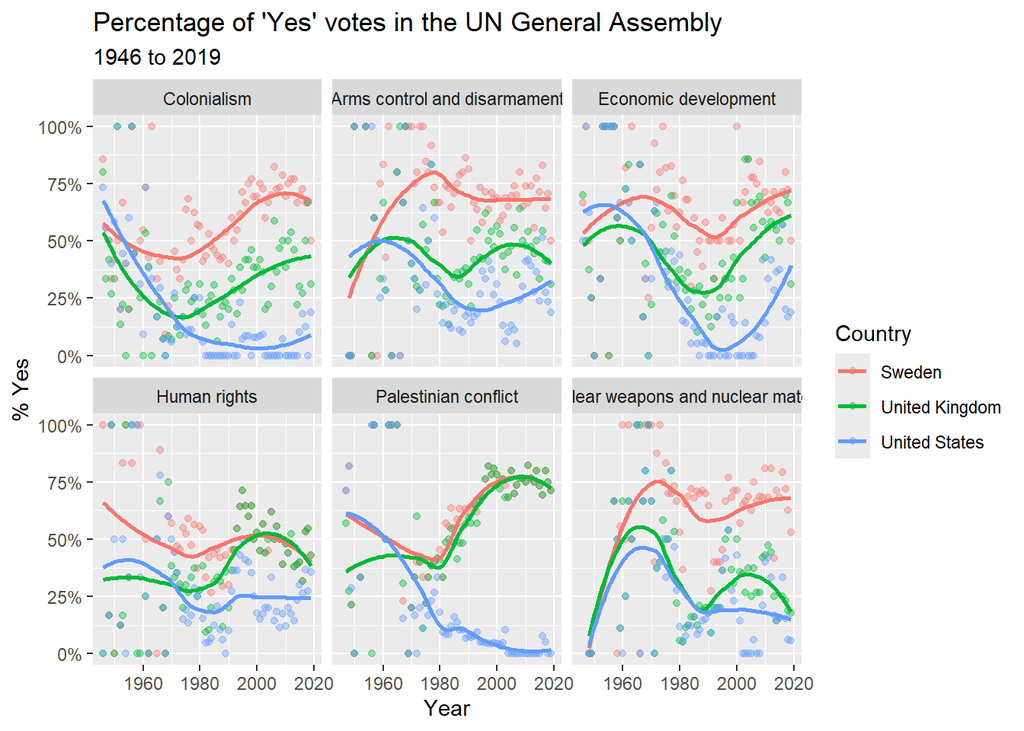

```r
library(tidyverse)
library(scales)
library(unvotes)

unvotes <- un_votes %>%
  inner_join(un_roll_calls, by = "rcid") %>%
  inner_join(un_roll_call_issues, by = "rcid")

unvotes %>%
  filter(country %in% c("United Kingdom", "United States", "Sweden")) %>%
  mutate(year = year(date)) %>%
  group_by(country, year, issue) %>%
  summarize(percent_yes = mean(vote == "yes")) %>%
  ggplot(mapping = aes(x = year, y = percent_yes, color = country)) +
  geom_point(alpha = 0.4) +
  geom_smooth(method = "loess", se = FALSE) +
  facet_wrap(~issue) +
  scale_y_continuous(labels = percent) +
  labs(
    title = "Percentage of 'Yes' votes in the UN General Assembly",
    subtitle = "1946 to 2019",
    y = "% Yes",
    x = "Year",
    color = "Country"
  )
```

Nüüd midagi praktilist: kui teil ei ole veel RStudios skriptifail lahti, siis avage uus skriptifail (*File* => *New File* => *R Script*) ja kopeerige joonise aluseks olev kood sinna. Leidke koodist käsk, mis määrab ära, milliste riikide andmed joonisel esitatakse ja lisage või asendage mõni joonisel olev riik mingi muu riigiga (nt Eestiga). Skriptifailis saate käske käivitada, viies kursori vastavale reale skriptifailis või märgistades skriptifailis vastava käsu ja vajutades `Ctrl + Enter`.

Võite katsetada erinevaid riikide kombinatsioone. Kuidas erinevate riikide hääletusmustrid erinevad? Kas Eesti hääletamisotsused on lähemal nt USA-le või mingitele Euroopa riikidele?

## Andmestiku R-i laadimine

Eelnevas harjutuses kasutasime andmeid, mis olid ühes paketis R-i kergesti sisse laetavad. Enamasti on meil siiski faili kujul andmestik, mida soovime R-s analüüsida. Vaatame ühe andmestiku näitel, kuidas R-s tööd korraldada, kui analüüsis on tarvis kasutada mingeid faile (ja reeglina on tarvis). Enne teeme aga RStudio seadetes ühe kasuliku muudatuse. Avage *Tools* => *Global Options* ja avanevas aknas eemaldage linnuke valiku *Restore .RData into workspace at startup* eest; selle all valige *Save workspace to .RData on exit* rippmenüüs *Never*.

[figure not shown]

Kasutame organisatsiooni Piirideta Reporterid ajakirjandusvabaduse indeksi 2022. aasta andmeid. Andmestik on Moodle’st allalaetavas zip-failis, kui selle lahti pakite, näete, et andmestik on kaustas `data`, nimega rsf_2022.csv (failiformaat csv tähendab *Comma Separated Values*). Kasutame andmete sisselugemiseks funktsiooni `read.csv2` (muus formaadis andmestike avamise jaoks on teised funktsioonid), mille puhul peame kindlasti täpsustama faili aadressi kõvakettal (argument `file`), igaks juhuks on hea täpsustada ka kodeering, et kõik tähemärgid korrektselt sisse loetud saaksid (`UTF-8` on reeglina kõige enamlevinud kodeering ja lollikindlam valik, aga tekstifailide puhul võib faili salvestamisel olla kasutatud ka muid kodeeringuid). Omistame andmestiku uuele objektile `pfi`.

Eelnevalt kirjeldatud andmete R-i laadimiseks ja R-s töö korraldamiseks on laias laastus kolm võimalust. Ütlen kohe ära, et neist kolmest tasub kindlasti eelistada viimast, seega kahte esimest võib proovida, aga võib ka proovimata jätta, oluline on käppa saada kolmas viis.

Esiteks, `read.csv2` käsus kogu faili asukoha defineerimine. Selleks, et R leiaks üles õige faili, saab ette anda kogu faili asukoha aadress, nt minu arvutis oleks see `"C:/indrek/ap_andmepadevus/ap_2023/ap_02_sissejuhatus_R/data/rsf_2022.csv"` (teie arvutites on see aadress muidugi midagi muud vastavalt sellele, kuhu andmefaili alla laadisite):

```r
pfi <- read.csv2(file = "C:/indrek/ap_andmepadevus/ap_2023/ap_02_sissejuhatus_R/data/rsf_2022.csv",
                 encoding = "UTF-8")
```

Pangem sealjuures tähele, et vastupidiselt failiaadressite tavaloogikale ei kasutata R-s failiaadressis langkriipse `\`, vaid kaldkriipse `/`, see on seetõttu, et langkriips on R-s reserveeritud muude operatsioonide jaoks (alternatiiv on siinkohal ka kasutada kahekordset langkriipsu `\\`).

Teiseks, kodukausta defineerimine. Tihtilugu on tarvis (erinevaid) faile üles laadida mitu korda, seetõttu on selline pika aadressiga jändamine tülikas, mistõttu parem alternatiiv oleks seadistada kodukaust üks kord ja alatiseks (st kuni RStudio sessiooni lõpuni ehk kuni RStudio kinni panen või seni, kuni pean vajalikuks kodukausta uuesti seadistada). Seda saab teha funktsiooniga `setwd`, käsuga `getwd()` saab kontrollida, milline kaust on parasjagu kodukaustaks.

```r
setwd("C:/indrek/ap_andmepadevus/ap_2023/ap_02_sissejuhatus_R")
pfi <- read.csv2(file = "data/rsf_2022.csv", encoding = "UTF-8")
```

Kolmandaks (laast, aga mitte liist): **projekt**. Eelnevatest variantidest oluliselt parem viis RStudios töövoo korraldamiseks on projekt. Uue projekti saate luua, kui valite *File* => *New Project* => *New Directory* => *New Project*, sisestate avanenud aknas projekti kaustale nime (nt `ap_01_sissejuhatus`) ja valite, kus see projekti kaust arvuti kõvakettal hakkab asetsema; vasakul all võiks linnukese panna ka kasti *Open in New Session*, seejärel klikkige *Create Project*.

Avaneb uus RStudio aken, kus alumises parempoolses aknas peaksite paanil *Files* nägema oma vastloodud projekti kausta sisu. Praegu on seal ainult fail projekti nimega ja laiendiga .Rproj. Tehke lahti File Explorer või muu failidega toimetamiseks mõeldud programm ja kopeerige Moodle’st alla laetud ja lahti pakitud zip-faili sisu (kaust `data` koos selle sees oleva andmefailiga) projektikausta. Kui vaatate seejärel RStudio projekti akent, näete, et projektikausta on lisaks .Rproj failile tekkinud ka kaust `data`. Nüüd on edasine andmete sisselugemine juba palju lihtsam, sest ei ole vaja välja kirjutada kogu failiaadressi.

Avage uus skriptifail *File* => *New File* => *R Script* ja kopeerige sinna allolev käsk ja käivitage see. Kuna andmed ei ole päris projekti juurkaustas, st samas kaustas, kus fail laiendiga `.Rproj`, vaid sealt edasi kaustas `data`, siis on allolevas käsus failinime ette lisatud `data/`:

```r
pfi <- read.csv2(file = "data/rsf_2022.csv", encoding = "UTF-8")
```

Selline töökorraldus, kus kõik failid on projektikaustas, teeb elu palju lihtsamaks, kui tuleb andmetöötluse käigus (mitme) failiga tegeleda või kui kasutate RStudiot mitmes arvutis või jagate oma faile kellegagi, sest kõik projektiga seotud failiaadressid on suhtelised (mitte absoluutsed), st ei ole vaja arvestada arvutiketta kaustastruktuuriga.

Skriptifaili saate salvestada *File* => *Save*, mõttekas oleks see salvestada projekti juurkausta.

## Töö andmestikuga

Andmestikke võib olla väga erineva struktuuriga, sotsiaalteadustes kasutatakse reeglina andmekogumeid, kus ridades on objektid ehk indiviidid (nt küsitlusuuringu andmestikus on tavaliselt igal real ühe vastaja vastused), veergudes on tunnused ehk muutujad (küsitlusuuringus on reeglina ühes tunnuses ühele küsimusele antud vastused). Sellist andmestruktuuri nimetatakse ka objekt-tunnus-maatriks, inglise keeles ka *tidy data*, R-s on sellise andmetüübi nimetuseks *data frame*, sellele lähedane andmetüüp R-s on ka *tibble* (andmetüüpidest räägime lähemalt edaspidi).

### Ülevaade andmetest

Esimese asjana uue andmestikuga töötades soovime tavaliselt saada mingisugust ülevaadet, mis andmed meil olemas on. Sellise esmase ülevaate saamiseks (st andmestikus olevatest tunnustest, nende võimalikest väärtustest) on hea kasutada funktsioone `head` ja `tail`, need annavad esimese/viimase kuue rea väärtused.

```r
head(pfi)
```

```
##   rank     country global_score political_context economic_context
## 1  156 Afghanistan        38.27             44.65            43.88
## 2  103     Albania        56.41             50.55            29.39
## 3  134     Algeria        45.53             41.21            32.40
## 4   53     Andorra        68.79             68.12            50.41
## 5   99      Angola        57.17             52.83            35.03
## 6   29   Argentina        77.28             76.36            51.53
##   legal_framework sociocult_context safety diff_2021           zone
## 1           42.54             43.33  16.96       -34 Asie-Pacifique
## 2           68.77             66.60  66.75       -20     UE Balkans
## 3           54.17             55.88  44.02        12           MENA
## 4           69.12             68.80  87.48       -14     UE Balkans
## 5           61.11             73.00  63.87         4        Afrique
## 6           90.68             85.75  82.06        40      Amériques
```

```r
tail(pfi)
```

```
##     rank       country global_score political_context economic_context
## 175   42 United States        72.74             72.99            59.33
## 176   44       Uruguay        72.03             70.30            49.32
## 177  133    Uzbekistan        45.74             44.75            35.71
## 178  159     Venezuela        37.78             33.70            31.73
## 179  174       Vietnam        26.11             32.32            18.71
## 180  169         Yemen        29.14             33.03            27.55
##     legal_framework sociocult_context safety diff_2021           zone
## 175           77.32             81.43  72.63         2      Amériques
## 176           83.63             72.33  84.58       -26      Amériques
## 177           50.88             53.33  44.03        24           EEAC
## 178           44.74             47.50  31.22       -11      Amériques
## 179           27.49             34.67  17.37         1 Asie-Pacifique
## 180           38.60             35.00  11.54         0           MENA
```

Näeme, et andmestikus on 10 veergu ehk tunnust, funktsiooniga `tail` saadud väljundi viimase rea alguses on arv 180, mis viitab sellele, andmestikus on 180 rida (muide, tunnuste ja ridade (ehk vaatluste) arvu näeb ka RStudio parema ülemise akna *Environment* paanilt, seal näidatakse parasjagu mälus olevaid objekte ja nende mõõtmeid). Igal real on erineva riigi andmed, sealjuures tundub, et read on sorteeritud riiginimede järgi (tunnus `country`) tähestikulises järjekorras. Lisaks on tunnus `rank`, mis tähistab riigi kohta ajakirjandusvabaduse pingereas tunnuse `global_score` väärtuse järgi, ja viis indeksi dimensiooni, mille põhjal on arvutatud koondindeksi väärtus (`political_context`, `economic_context`, `legal_framework`, `sociocult_context` ja `safety`). Viimastena on andmestikus `diff_2021`, mis näitab riigi edetabelikoha erinevust eelneva aastaga, ja tunnus `zone`, mis näitab regiooni, kus riik asub.

Rohkem ridu andmestikust näeksime, käivitades (nt sisestades käsureale) lihtsalt andmestiku nime `pfi`. Ridu on andmestikus siiski liiga palju, et R vaikeseadena neid kõiki näitaks. Kui sooviksime ikkagi kõiki näha, võiks kasutada käsku `View(pfi)` (NB! Funktsioon `View` on suure algustähega), mis avab andmestiku skriptiaknas eraldi paanil.

### Tunnuste valimine

Nii koondindeks kui selle aladimensioonid näikse olevat mõõdetud skaalal nullist sajani, kontrollime selle üle: valime vastavad tunnused funktsiooniga `select` (mis on paketis `dplyr`) ja funktsiooniga `summary` tellime mõned jaotusparameetrid, mille hulgas on ka miinimum- ja maksimumväärtus. Antud hetkel pole paketti `dplyr` eraldi vaja installeerima ega sisse laadima hakata, sest eelnevalt installeerisime ja laadisime sisse paketi `tidyverse`, mis on õieti pakettide kogum, sellesse kogumisse kuulub ka pakett `dplyr`.

Funktsiooni `select` esimeseks argumendiks on vaja sisestada andmestik, teiseks argumendiks tunnused, mille valime; antud juhul soovime valida mitu andmestikus järjestikku asetsevat tunnust, sel puhul saame sisestada neist esimese ja viimase tunnuse nime ning nende vahele kooloni.

```r
summary(select(pfi, global_score:safety))
```

```
##   global_score   political_context economic_context legal_framework
##  Min.   :13.92   Min.   :22.22     Min.   : 0.00    Min.   :15.79
##  1st Qu.:45.36   1st Qu.:43.79     1st Qu.:32.76    1st Qu.:51.67
##  Median :59.15   Median :55.67     Median :42.11    Median :65.94
##  Mean   :58.24   Mean   :57.01     Mean   :45.00    Mean   :62.45
##  3rd Qu.:71.12   3rd Qu.:70.08     3rd Qu.:54.05    3rd Qu.:77.46
##  Max.   :92.65   Max.   :94.89     Max.   :90.38    Max.   :92.23
##  sociocult_context     safety
##  Min.   :12.00     Min.   : 4.63
##  1st Qu.:54.88     1st Qu.:41.06
##  Median :68.90     Median :66.67
##  Mean   :66.35     Mean   :60.37
##  3rd Qu.:81.23     3rd Qu.:80.15
##  Max.   :95.00     Max.   :96.46
```

Näeme, et tõepoolest, nii koond- kui alaindeksid on ilmselt arvutatud skaalal, kus miinimum on 0 ja maksimum 100 (sealjuures ühe riigi puhul on pressivabadust mõjutavad majanduskeskkonna tegurid hinnatud lausa nulliga).

### *Pipe* `%>%`

Kasutasime siinkohal kahte erinevat funktsiooni, millest ühe (`select`) tulemuse (kuus tunnust algsest andmestikust) edastasime n-ö väljaspool asetsevale funktsioonile `summary` (mis arvutas jaotusparameetrid). Selliste pesastatud käskude asemel on lihtsam ja selgem kasutada n-ö `pipe`e (torusid? Tunnen vajadust hea eestikeelse tõlke järele) ehk sümbolite kombinatsiooni `%>%` (klahvikombinatsioon `Ctrl + Shift + M`, Macil `Cmd + Shift + M`):

```r
select(pfi, global_score:safety) %>%
  summary()
```

Selle tööpõhimõte on, et esimesel real oleva käsu tulemus edastatakse järgnevale reale. Kui järgneva rea funktsioonis on rohkem argumente kui üks, edastatakse eelneva rea tulemus järgneva rea funktsiooni esimesele argumendile. Võib-olla selgemalt saaks seda kirjutada nii (tulemus on täpselt sama):

```r
pfi %>%
  select(global_score:safety) %>%
  summary()
```

Vahemärkus: vahel näete R-ga seotud materjalides kasutatavat ka toru `|>`, mis teeb täpselt sama. Erinevus on ainult selles, et `|>` on olemas R-i baasversioonis, samas kui `%>%` jaoks on vajalik sisse laadida pakett `tidyverse`. Selles mõttes on `|>` kasutada lihtsam, samas nt ma ise olen harjunud `%>%`-ga.

#### Harjutus 2

##### Ülesanne

Ütleme, et meid huvitab eelkõige, milline on erinevate riikide skoor just ajakirjanike ohutuse dimensioonis. Eelnevalt saime kogu funktsiooniga `View()` näha hõlpsalt kogu andmestikku, aga riikide nimed olid tabeli ühes servas, ohutuse skoorid teises servas – pole kuigi ülevaatlik. Koostage tabel, kus oleks ainult riikide nimed ja ohutuse skoorid ja avage see funktsiooniga `View()` eraldi paanil.

##### Vihje

Ülesande lahendamiseks saab kasutada funktsioone `select` ja `View`.

##### Tulemus

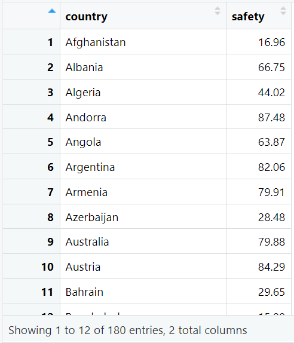

### Andmestiku sorteerimine

Oleme saanud mingi ülevaate tunnustest (kes soovib sisulisemalt teada saada, mida need tunnused mõõdavad, võib vaadata [siia](https://rsf.org/en/index-methodologie-2022?year=2022&data_type=general)), ilmselt järgmisena huvitab meid riikide pingerida ja millisel kohal asub Eesti. Riigid on aga reastatud tähestikulises järjekorras, seega on meil vaja riigid sorteerida nende asukoha järgi ajakirjandusvabaduse pingereas. Kasutame selleks paketi `dplyr` funktsiooni `arrange`, mille esimeseks argumendiks anname andmestiku nime, teiseks tunnuse, mille järgi andmed sorteerime.

```r
arrange(pfi, rank)
```

```r
pfi <- arrange(pfi, rank)
```

Kui vaatame nüüd `View(pfi)` (kui andmestik oli varasemast eraldi paanil funktsiooniga `View` juba avatud, ei ole käsku tarvis korrata, vaid saab minna lihtsalt sellele paanile; sorteerimisega andmestikku tehtud muutused kajastuvad andmetabelis automaatselt), on riigid soovitud järjestuses. Näeme nt, et tabeli esimese 30 riigi seas on valdavalt EL-i/Lääne-Euroopa riigid, aga on ka nt sellised riigid nagu Jamaika, Seišellid ja Ida-Timor.

#### Harjutus 3

##### Ülesanne

Võtke aluseks eelmises harjutuses tehtud kahe tunnusega tabel. Reastage selles riigid ohutuse skooride järgi. Lahendage ülesanne seekord nii, et käsu väljund ei tule eraldi paanile (nagu funktsiooniga `View()`), vaid konsooli.

##### Vihje

Kui omistasite kahe tunnusega tabeli eelnevalt uuele objektile, siis piisab antud ülesandes funktsioonist `arrange`. Kui eelnevalt omistamist ei teinud, siis on lisaks siin tarvis kasutada funktsiooni `select` (pmst kopeerida eelmise ülesande lahenduseks olev käsk, eemaldada sealt käsk `View` ja lisada `arrange`).

##### Tulemus

```
##                          country safety
## 1                        Myanmar   4.63
## 2                         Mexico  11.02
## 3                        Eritrea  11.36
## 4                          Yemen  11.54
## 5                    North Korea  12.38
## 6                          Syria  13.39
## 7                           Iran  13.61
## 8                          China  15.84
## 9                     Bangladesh  15.88
## 10                   Afghanistan  16.96
## 11                       Vietnam  17.37
## 12                         Egypt  17.64
## 13                      Pakistan  17.75
## 14                       Somalia  18.27
```

[output cut: 166 more lines]

### Andmestiku filtreerimine, loogilised tehted

Kui soovime näha mingi konkreetse riigi või riikide andmeid, saame kasutada paketi `dplyr` funktsiooni `filter` (tasub meelde jätta: veergude ehk tunnuste valimiseks oli funktsioon `select`, ridade ehk indiviidide valimiseks on funktsioon `filter`). Sellega peame kirja panema tingimuse(d), mille vastavad need indiviidid, mille andmeid soovime näha. Pange tähele, et väärtuse võrdumise tingimuse puhul on R-s vastav loogiline operaator `==`, mitte `=` (väike detail, mis võib ikka ja jälle kahe silma vahele jääda ja tulemuseks veateate anda).

```r
filter(pfi, country == "Japan")
```

```
##   rank country global_score political_context economic_context legal_framework
## 1   71   Japan        64.37             54.66             53.7           66.23
##   sociocult_context safety diff_2021           zone
## 1             67.06  80.19        -4 Asie-Pacifique
```

Võime siin kasutada ka *pipe*’i, tulemus on sama:

```r
pfi %>%
  filter(country == "Japan")
```

```
##   rank country global_score political_context economic_context legal_framework
## 1   71   Japan        64.37             54.66             53.7           66.23
##   sociocult_context safety diff_2021           zone
## 1             67.06  80.19        -4 Asie-Pacifique
```

Kui soovime näha mitte kõiki Jaapani andmeid, vaid ainult nt tema kohta edetabelis, saame lisaks kasutada funktsiooni `pull`, mis eraldab ainult ühe tunnuse väärtuse:

```r
pfi %>%
  filter(country == "Japan") %>%
  pull(rank)
```

```
## [1] 71
```

Kui soovime näha rohkem kui ühe riigi andmeid korraga, tuleb kasutada mitut tingimust (sümbol `|` vastab loogilisele operaatorile OR ehk andmestikust võetakse välja read, mis vastavad ühele VÕI teisele tingimusele):

```r
pfi %>%
  filter(country == "Vietnam" | country == "Thailand")
```

```
##   rank  country global_score political_context economic_context legal_framework
## 1  115 Thailand        50.15             58.99            45.24           47.37
## 2  174  Vietnam        26.11             32.32            18.71           27.49
##   sociocult_context safety diff_2021           zone
## 1             53.67  45.50        22 Asie-Pacifique
## 2             34.67  17.37         1 Asie-Pacifique
```

Kui riike on rohkem, on lihtsam kasutada operaatorit `%in%` (riikide nimed tuleb siin siduda kokku üheks vektoriks funktsiooniga `c`, vektor on üks (kõige lihtsam) andmehulga tüüp, millega tutvume lähemalt järgmisel korral):

```r
pfi %>%
  filter(country %in% c("Vietnam", "Thailand", "Cambodia", "Laos", "Myanmar"))
```

```
##   rank  country global_score political_context economic_context legal_framework
## 1  115 Thailand        50.15             58.99            45.24           47.37
## 2  142 Cambodia        43.48             42.42            27.96           49.65
## 3  161     Laos        36.64             36.06            20.92           31.58
## 4  174  Vietnam        26.11             32.32            18.71           27.49
## 5  176  Myanmar        25.03             40.40            29.25           20.18
##   sociocult_context safety diff_2021           zone
## 1             53.67  45.50        22 Asie-Pacifique
## 2             62.40  34.96         2 Asie-Pacifique
## 3             44.00  50.64        11 Asie-Pacifique
## 4             34.67  17.37         1 Asie-Pacifique
## 5             30.67   4.63       -36 Asie-Pacifique
```

Filtreerida saab loomulikult ka arvuliste väärtuste alusel. Näiteks peaks Piirideta Reporteri hinnangu järgi riigid, mille koondindeksi skoor on vähemalt 85 punkti, olema hea pressivabaduse astmega; sellest väiksema, kuid koondindeksi väärtusega vähemalt 70 punkti peaks olema rahuldava pressivabaduse astmega riigid. Vaatame, millised riigid nendesse kahte gruppi kuuluvad. Pange tähele, et tekstilised väärtused ümbritsesime loogilistes tehetes jutumärkidega, arvuliste väärtuste puhul jutumärke ei kasutata.

```r
pfi %>%
  filter(global_score >= 70) %>%
  pull(country)
```

```
##  [1] "Norway"              "Denmark"             "Sweden"
##  [4] "Estonia"             "Finland"             "Ireland"
##  [7] "Portugal"            "Costa Rica"          "Lithuania"
## [10] "Liechtenstein"       "New Zealand"         "Jamaica"
## [13] "Seychelles"          "Switzerland"         "Iceland"
## [16] "Germany"             "Timor-Leste"         "Namibia"
## [19] "Canada"              "Czech Republic"      "Luxembourg"
## [22] "Latvia"              "Belgium"             "United Kingdom"
## [25] "Trinidad and Tobago" "France"              "Slovakia"
## [28] "Netherlands"         "Argentina"           "Dominican Republic"
## [31] "Austria"             "Spain"               "Bhutan"
## [34] "Guyana"              "South Africa"        "Cabo Verde"
## [37] "Ivory Coast"         "Taiwan"              "Australia"
## [40] "Moldova"             "Burkina Faso"        "United States"
## [43] "South Korea"         "Uruguay"             "Samoa"
## [46] "Sierra Leone"        "Belize"              "Croatia"
```

Kuna sorteerisime andmestiku enne edetabelikoha järgi, siis esitatakse siin meile riikide nimed samuti selles järjestuses.

Tabel 1. Põhilised loogilised operaatorid.

| Operaator | Tähendus |
| --- | --- |
| == | võrdne |
| != | mitte võrdne |
| > | suurem kui |
| < | väiksem kui |
| >= | suurem või võrdne kui |
| <= | väiksem või võrdne kui |
| & | ja |
| `\|` | või |

Teeme nüüd mõned harjutused filtreerimise kohta.

#### Harjutus 4

##### Ülesanne

Leia, milliste vähemalt rahuldava koondindeksi skooriga riikide koht pingereas võrreldes eelneva aastaga paranes. Andmed eelneva aastaga võrdluse kohta on tunnuses `diff_2021`, kus positiivne väärtus tähistab eelneva aastaga võrreldes pingereas paremat kohta, negatiivne väärtus kehvemat kohta. Lahenda ülesanne nii, et väljundiks saaksid ainult tingimustele vastavate riikide nimed.

##### Vihje

Antud ülesandes on tarvis andmestikku filtreerida (tunnuste `global_score` ja `diff_2021` alusel) ja seejärel kasutada funktsiooni `pull`, et saada väljundisse andmestikku jäänud riikide nimed.

##### Tulemus

```
##  [1] "Denmark"             "Estonia"             "Ireland"
##  [4] "Portugal"            "Lithuania"           "Liechtenstein"
##  [7] "Seychelles"          "Iceland"             "Timor-Leste"
## [10] "Namibia"             "Czech Republic"      "United Kingdom"
## [13] "Trinidad and Tobago" "France"              "Slovakia"
## [16] "Argentina"           "Dominican Republic"  "Bhutan"
## [19] "Guyana"              "Ivory Coast"         "Taiwan"
## [22] "Moldova"             "United States"       "Sierra Leone"
## [25] "Belize"              "Croatia"
```

#### Harjutus 5

##### Ülesanne

Võttes aluseks eelneva ülesande lahenduse, muuda seda nii, et väljundis oleks näha mitte ainult tingimustele vastavate riikide nimed, vaid ka nende riikide koondindeksi skoorid ja võrdlus eelmise aasta kohaga pingereas.

##### Vihje

Lahendus on eelmise ülesandega samasugune, ainult selle vahega, et siin soovime andmestikust eraldada mitte ühe, vaid mitme tunnuse andmed. Millist funktsiooni peaksime siin funktsiooni `pull` asemel kasutama?

##### Tulemus

```
##                country global_score diff_2021
## 1              Denmark        90.27         2
## 2              Estonia        88.83        11
## 3              Ireland        88.30         6
## 4             Portugal        87.07         2
## 5            Lithuania        84.14        19
## 6        Liechtenstein        84.03        13
## 7           Seychelles        83.33        39
## 8              Iceland        82.69         1
## 9          Timor-Leste        81.89        54
## 10             Namibia        81.84         6
## 11      Czech Republic        80.54        20
## 12      United Kingdom        78.71         9
## 13 Trinidad and Tobago        78.68         6
## 14              France        78.53         8
## 15            Slovakia        78.37         8
## 16           Argentina        77.28        40
## 17  Dominican Republic        76.90        20
## 18              Bhutan        76.46        32
## 19              Guyana        76.41        17
## 20         Ivory Coast        74.46        29
## 21              Taiwan        74.08         5
## 22             Moldova        73.47        49
## 23       United States        72.74         2
## 24        Sierra Leone        71.03        29
## 25              Belize        70.67         6
## 26             Croatia        70.42         8
```